# XGBoost

This notebook tries to implement XGBoost through `xgboost` library and at the same time try to understand the tuning parameter

## 1. Load the Library

```python
import xgboost as xgb
from sklearn.metrics import mean_squared_error
import pandas as pd
import numpy as np
from sklearn.datasets import load_boston
from sklearn.model_selection import train_test_split
import matplotlib.pyplot as plt
```

```python
boston = load_boston()
```

```python
# Generate Data
data = pd.DataFrame(boston.data)
data.columns = boston.feature_names
data['PRICE'] = boston.target
X, y = data.iloc[:,:-1],data.iloc[:,-1]
X_train, X_test, y_train, y_test = train_test_split(X, y, test_size=0.2, random_state=123)
```

```python
data.head()
```

|  | CRIM | ZN | INDUS | CHAS | NOX | RM | AGE | DIS | RAD | TAX | PTRATIO | B | LSTAT | PRICE |
| --- | --- | --- | --- | --- | --- | --- | --- | --- | --- | --- | --- | --- | --- | --- |
| 0 | 0.00632 | 18.0 | 2.31 | 0.0 | 0.538 | 6.575 | 65.2 | 4.0900 | 1.0 | 296.0 | 15.3 | 396.90 | 4.98 | 24.0 |
| 1 | 0.02731 | 0.0 | 7.07 | 0.0 | 0.469 | 6.421 | 78.9 | 4.9671 | 2.0 | 242.0 | 17.8 | 396.90 | 9.14 | 21.6 |
| 2 | 0.02729 | 0.0 | 7.07 | 0.0 | 0.469 | 7.185 | 61.1 | 4.9671 | 2.0 | 242.0 | 17.8 | 392.83 | 4.03 | 34.7 |
| 3 | 0.03237 | 0.0 | 2.18 | 0.0 | 0.458 | 6.998 | 45.8 | 6.0622 | 3.0 | 222.0 | 18.7 | 394.63 | 2.94 | 33.4 |
| 4 | 0.06905 | 0.0 | 2.18 | 0.0 | 0.458 | 7.147 | 54.2 | 6.0622 | 3.0 | 222.0 | 18.7 | 396.90 | 5.33 | 36.2 |

## 2. Model Training

XGBoost has lots of hyperparameters. Normally we divide it into three groups:

1. General Parameters:
   - `booster=gbtree`: Choose the weaker leaner: `gbtree` or `gblinear`
   - `silent=0`: 1 for no running log info
2. Booster Parameters:
   - `learning_rate=0.3`: step size shrinkage used to prevent overfitting. Range is [0,1]
   - `max_depth=6`: determines how deeply each tree is allowed to grow during any boosting round.
   - `subsample=1`: percentage of samples used per tree. Low value can lead to underfitting. Range is (0,1]
   - `colsample_bytree=1`: percentage of features used per tree. High value can lead to overfitting.
   - `n_estimators`: number of trees you want to build.
   - `gamma=0`: controls whether a given node will split based on the expected reduction in loss after the split. A higher value leads to fewer splits. Supported only for tree-based learners.
   - `alpha`: L1 regularization on leaf weights. A large value leads to more regularization.
   - `lambda`: L2 regularization on leaf weights and is smoother than L1 regularization.
3. Learning Task Parameters:
   - `objective=reg:squarederror`: determines the loss function to be used like reg:linear for regression problems, reg:logistic for classification problems with only decision, binary:logistic for classification problems with probability.
   - `metric`: The metric to be used for validation data, such as: rmse, mae, logloss, error

```python
xg_reg = xgb.XGBRegressor(objective ='reg:squarederror', colsample_bytree = 0.7, learning_rate = 0.1,
                max_depth = 5, alpha = 10, n_estimators = 10)
```

```python
xg_reg.fit(X_train,y_train)
preds = xg_reg.predict(X_test)
```

```python
rmse = np.sqrt(mean_squared_error(y_test, preds))
print("RMSE: {}".format(rmse))
```

```
RMSE: 9.656435145869283
```

## 3. Model Validation

`xgboost` can also do cross validation:

- `num_boost_round`: denotes the number of trees you build (analogous to n_estimators)
- `metrics`: tells the evaluation metrics to be watched during CV
- `as_pandas`: to return the results in a pandas DataFrame.
- `early_stopping_rounds`: finishes training of the model early if the hold-out metric ("rmse" in our case) does not improve for a given number of rounds.
- `seed`: for reproducibility of results.

```python
data_dmatrix = xgb.DMatrix(data=X,label=y)
```

```python
params = {'objective':'reg:squarederror','colsample_bytree': 0.7,'learning_rate': 0.1,
                'max_depth': 5, 'alpha': 10}

cv_results = xgb.cv(dtrain=data_dmatrix,
                    params=params,
                    nfold=3,
                    num_boost_round=50,
                    early_stopping_rounds=10,
                    metrics="rmse",
                    as_pandas=True,
                    seed=123)
```

```python
cv_results.tail()
```

|  | test-rmse-mean | test-rmse-std | train-rmse-mean | train-rmse-std |
| --- | --- | --- | --- | --- |
| 45 | 3.581326 | 0.339733 | 1.770831 | 0.006182 |
| 46 | 3.566893 | 0.345902 | 1.742025 | 0.004021 |
| 47 | 3.554664 | 0.345619 | 1.713263 | 0.005822 |
| 48 | 3.540806 | 0.350308 | 1.686923 | 0.006609 |
| 49 | 3.530053 | 0.349713 | 1.663324 | 0.008643 |

## 4. Model Visualization

XGBoost has a `plot_tree()` function that makes this type of visualization easy. Once you train a model using the XGBoost learning API, you can pass it to the `plot_tree()` function along with the number of trees you want to plot using the num_trees argument

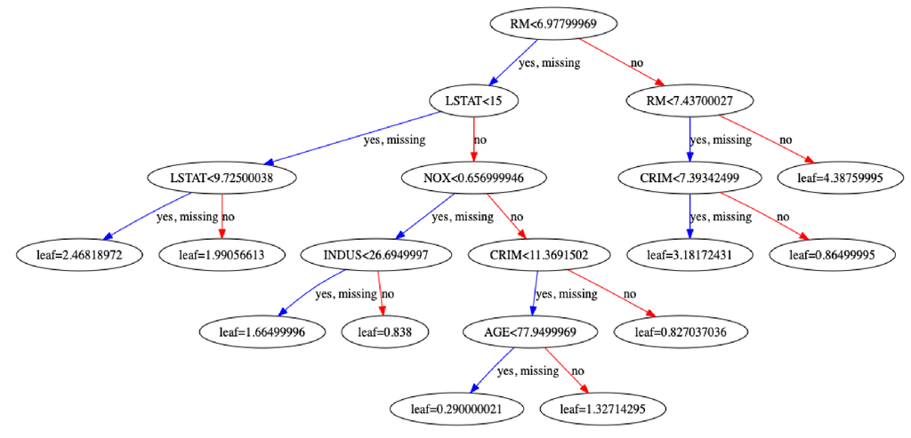

```python
xgb.plot_tree(xg_reg,num_trees=0)
plt.rcParams['figure.figsize'] = [100, 20]
plt.show()
```

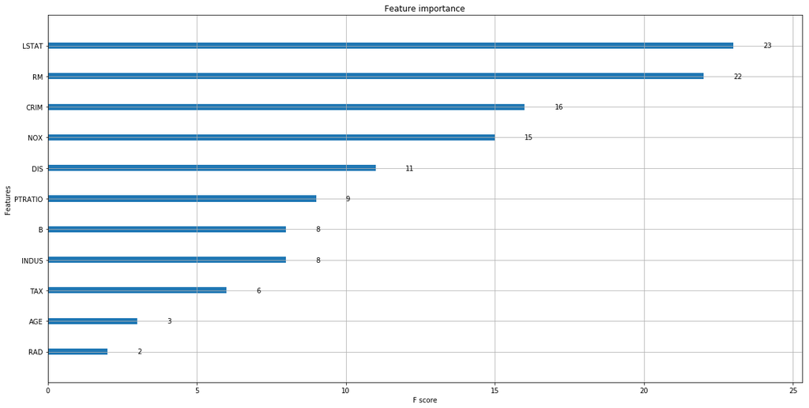

```python
xgb.plot_importance(xg_reg)
plt.rcParams['figure.figsize'] = [20, 5]
plt.show()
```